# Auditoria T��cnica Senex AI v5.1.0

# 3. Sistema Bilingue PT/EN

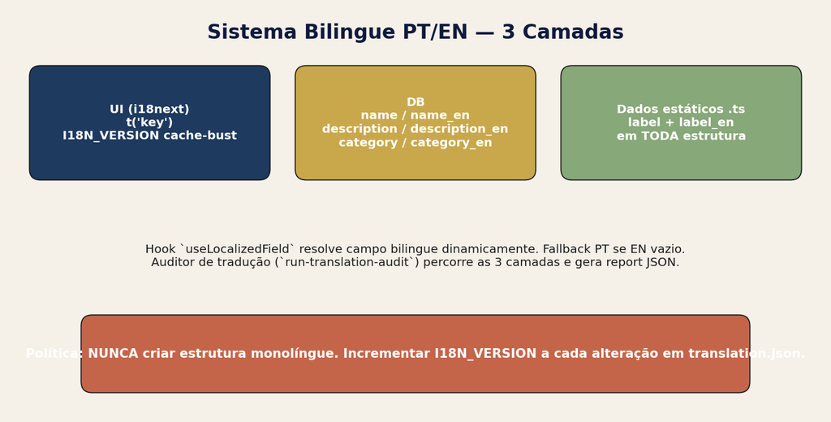

Bilingue 3 camadas

## 3.1 Política

- **Camada UI:** `useTranslation()` + `t('key')`. Nunca textos hardcoded.
- **Camada DB:** colunas pares `name`/`name_en`, `description`/`description_en`, `category`/`category_en`.
- **Camada estática `.ts`:** todo array/objeto exposto na UI carrega `label_en`/`name_en` ao lado.

## 3.2 Cache-busting

O arquivo `src/i18n.ts` mantém `I18N_VERSION` que **DEVE** ser incrementado a qualquer mudança em `translation.json`. A constante é gravada em `localStorage` e força o reload de traduções quando muda — sem ela o browser serve traduções obsoletas.

## 3.3 Auditor

A edge function `run-translation-audit` percorre as 3 camadas e gera `public/translation-audit-report.json` com chaves faltantes, traduções defasadas e duplicatas. Executado a cada release.

## 3.4 Hook `useLocalizedField`

```typescript
const display = useLocalizedField(condition, 'name'); // → name ou name_en conforme i18n.language
```

Fallback automático para PT quando EN está vazio.

# 4. Motor de Recomendação Híbrida

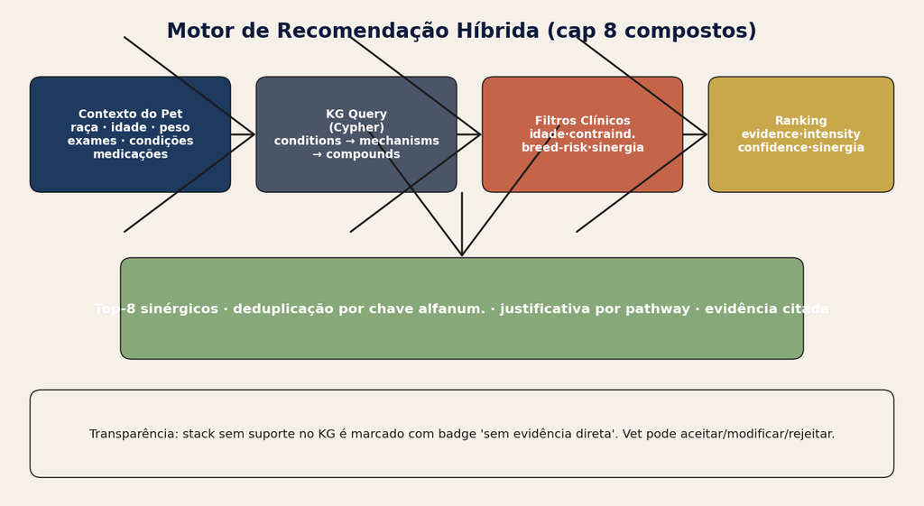

Recomendação híbrida

## 4.1 Fluxo

1. **Contexto do pet** é montado a partir de `pet_profiles` + `pet_conditions` + `pet_exams` + `pet_medications`.
2. **Query Cypher** percorre o KG: `condition → mechanism → compound`, deduplicando arestas por confidence.
3. **Filtros clínicos** removem candidatos com contraindicação por idade, breed-risk ativo, ou interação com medicação corrente.
4. **Ranking** combina `evidence_level × intensity × confidence × sinergia` (peso 0.3/0.2/0.2/0.3).
5. **Cap de 8** compostos — limite operacional de adesão (tutor não toma mais que 8).
6. **Deduplicação alfanumérica** evita duplicatas como “NMN” vs “Nicotinamide Mononucleotide”.

## 4.2 Transparência

Stacks sem suporte direto do KG (apenas inferência LLM) recebem badge **“sem evidência direta”**. O vet pode **aceitar · modificar · rejeitar** via `vet-recommendation-stack-management`. Toda alteração registra `vet_reviewed_by` + `vet_reviewed_at`.

# 5. Digital Twin de Longevidade

[figure not shown]

Digital Twin Gompertz

## 5.2 Output clínico

- **Mediana de vida baseline vs com stack** (curva visualizada acima)
- **`years_gained` esperado** (intervalo de confiança 80%)
- **Custo evitado projetado** (BRL, baseado em literatura de doenças prevenidas)
- **Sigmóide de outcome** por condição (`Evidence Projection Engine`)

## 5.3 Trigger para gap-fill

Quando `years_gained < threshold` (padrão 0.3), o sistema dispara o pipeline de gap-fill da seção 6.

# 6. Gap-Fill PubMed + Gemini

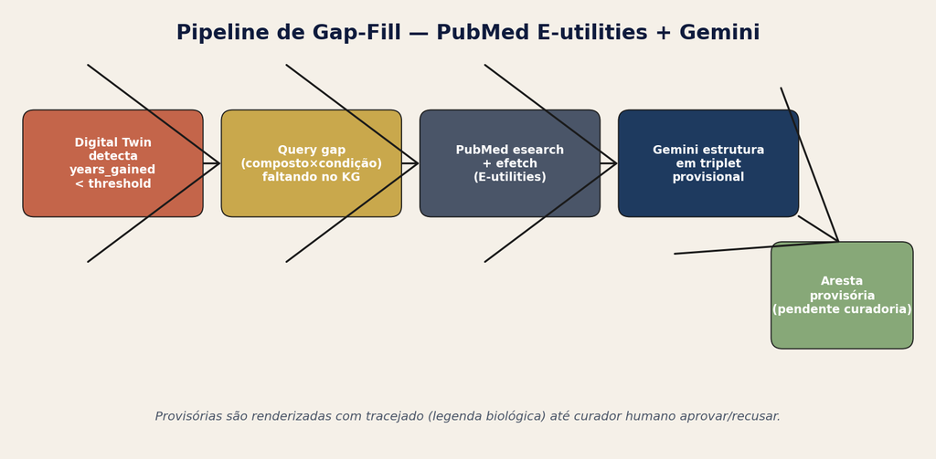

Gap-fill pipeline

## 6.1 Quando

Sempre que o Digital Twin retorna `years_gained_proxy` baixo para uma combinação `(composto × condição)` que tem pares parecidos cobertos no KG → existe um buraco na ontologia.

## 6.2 Como

1. `kg-missing-triplets` enumera os pares faltantes priorizando alta prevalência clínica.
2. `pubmed-esearch` + `pubmed-efetch` (E-utilities) trazem abstracts.
3. `gemini-structure-pubmed` extrai triplet provisional com `source_excerpt` + DOI.
4. Inserido em `triplet_extractions` com `provisional=true` → renderizado **tracejado** no KG até curador humano aprovar.

# 7. Taxonomia Padronizada — SNOMED-CT VetSCT + UMLS

- **SNOMED-CT VetSCT** governa nomes canônicos de condições (`Osteoarthritis`, `Chronic Kidney Disease`).
- **UMLS** governa pathways (`NF-κB signaling`, `mTOR pathway`).
- **`biomedical-taxonomy.ts`** mantém o dicionário local + regex de classificação multi-tier.
- **Reclassificação durante sync** ao Neo4j corrige erros de modelo e impõe snake_case.

# 8. Conformidade Regulatória

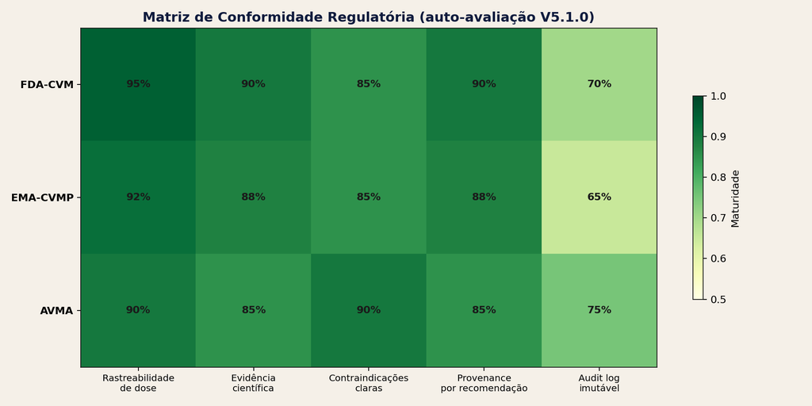

Matriz de conformidade

Auto-avaliação contra os 3 marcos regulatórios mais relevantes (FDA-CVM, EMA-CVMP, AVMA). Nenhum dos itens é apenas declaratório — todos têm artefato auditável (tabela, função, log).

| Requisito | Implementação |
| --- | --- |
| Rastreabilidade de dose | `pet_medications` + `dosage-resolver` |
| Evidência científica | `scientific_studies` + `triplet_extractions.source_excerpt` |
| Contraindicações claras | `nutraceutical_conditions.contraindication_*` + filtros de ranking |
| Provenance por recomendação | toda aresta usada em recomendação carrega `source_triplet_id` |
| Audit log imutável | soft-delete + `audit_requests`/`technical_audits` |

**Gap conhecido:** “Audit log imutável” está em 65–75% — falta append-only enforcement em DB-level (atualmente é convenção aplicacional).

# 9. Forças (18)

1. **Pipeline determinístico de 7 estágios** com responsabilidade única por edge function.
2. **Gatekeeper de curadoria** — invariante que impede triplets <0.50 de chegarem ao KG público.
3. **Modelo de 5 camadas causais** — base da explicabilidade clínica.
4. **245 políticas RLS ativas** cobrindo 93 tabelas.
5. **`has_role()` SECURITY DEFINER** evita loops recursivos de RLS.
6. **GRANT explícito** em toda migration que cria tabela — invariante documentado.
7. **Sistema bilingue em 3 camadas** (UI · DB · estática) com auditor automático.
8. **Cache-busting i18n** via `I18N_VERSION` incrementável.
9. **Cap de 8 compostos** alinhado à literatura de adesão.
10. **Digital Twin Gompertz por raça** — projeção quantitativa, não narrativa.
11. **Gap-fill PubMed automático** com aresta provisional + tracejado visual.
12. **Vet-curator dialog** com evidência computada em tempo real (sem LLM no path crítico).
13. **SNOMED-CT VetSCT + UMLS** como ontologias canônicas.
14. **Pet sintéticos (660 em 11 cohorts)** ordenados por complexidade crescente.
15. **No-mock policy** — dados clínicos sempre rotulados pela origem (DB, LLM, regra).
16. **Soft delete + safeguard “DELETE”** para deleção em massa de estudos aprovados.
17. **Predicate mapping** normaliza variantes LLM antes da validação.
18. **38.643 arestas hierárquicas** com provenance completa (estudo + chunk).